# Bayesian Project

Andrew

2026-11-08

```r
#Packages and libraries

#install.packages("ggplot2")
#install.packages("plotly", dependencies = TRUE)
#install.packages("rgl")

library(ggplot2)
#library(plotly)

#install.packages("knitr")
library(knitr)
```

The model that we are trying to fit is

y=alpha + beta_1**x_1 + beta_2**x_2 + epsilon

epsilon~N(0, 1/tau)

We want to take 1000 posterior samples based on 80000 simulated sets of parameter values from the prior

```r
K<-80000 #No. of prior samples
nsamples <-1000 # No. of posterior samples to take

set.seed(115)

pred_point <-3.0 # value at which to compute the predictive distribution
```

Set up of true parameter values, generate data from these (we wont know these if we where given a data set but in a simulation study we want to show our code can give these values)

```r
truealpha=1.5
truebeta_1=2.0
truebeta_2=5.0

truetau=1.0
```

Prior parameters: normal on alpha and beta, gamma on tau

```r
alphamean=0
alphavar = 100
beta_1mean=0
beta_1var=100
beta_2mean = 2.0
beta_2var = 100
taushape=0.5
tauscale=0.5
```

To set up the data we need to use the true parameter values and set up what x is going to be

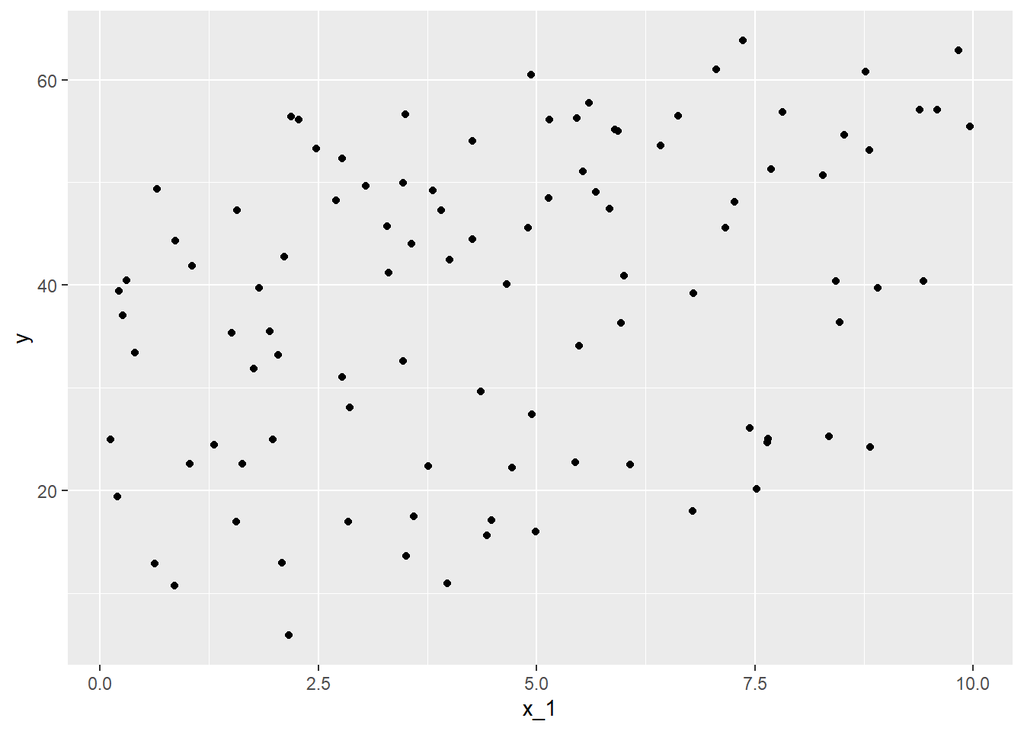

```r
x_1 <- round(runif(100, 0, 10), 2)

x_2 <- round(runif(100, 0, 10), 2)


n = length(x_1)
y<-truealpha + truebeta_1*x_1 + truebeta_2*x_2 + rnorm(n,0,sd = sqrt((1/truetau)))
data<-data.frame(y,x_1, x_2)


fit <- lm(y ~ x_1 + x_2)

ggplot(data, aes(x_1,y))+geom_point()
```

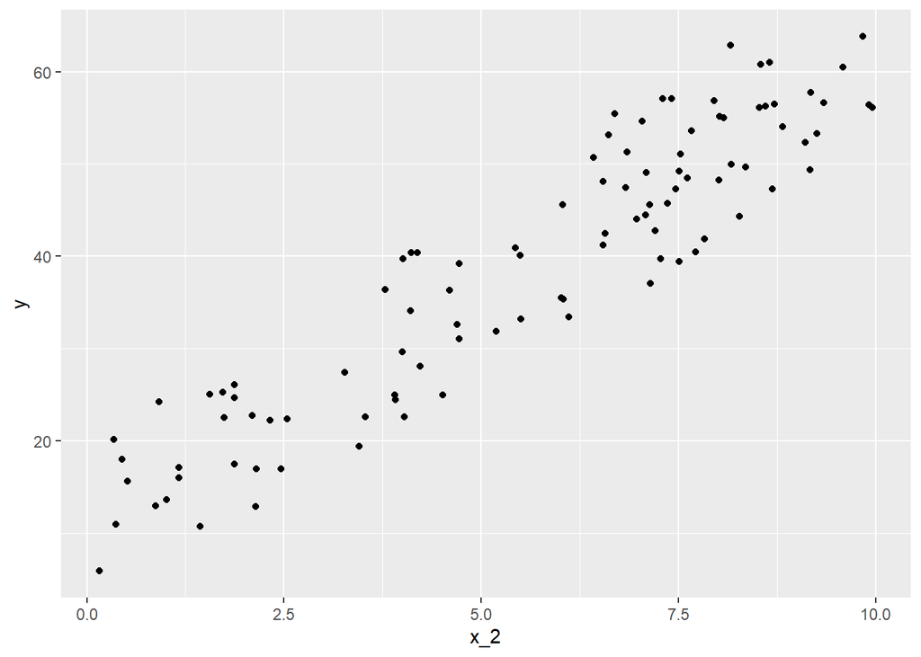

```r
ggplot(data, aes(x_2,y))+geom_point()
```

Maximum Likelihood:

```r
# Time the ML fit
t_ml <- system.time({
  ml_fit <- lm(y ~ x_1 + x_2)
})

summary(ml_fit)
```

```
##
## Call:
## lm(formula = y ~ x_1 + x_2)
##
## Residuals:
##     Min      1Q  Median      3Q     Max
## -2.0873 -0.5734  0.0509  0.5538  2.7828
##
## Coefficients:
##             Estimate Std. Error t value Pr(>|t|)
## (Intercept)  1.67714    0.27338   6.135 1.85e-08 ***
## x_1          1.99744    0.03561  56.084  < 2e-16 ***
## x_2          5.01180    0.03464 144.672  < 2e-16 ***
## ---
## Signif. codes:  0 '***' 0.001 '**' 0.01 '*' 0.05 '.' 0.1 ' ' 1
##
## Residual standard error: 0.9663 on 97 degrees of freedom
## Multiple R-squared:  0.9959, Adjusted R-squared:  0.9958
## F-statistic: 1.183e+04 on 2 and 97 DF,  p-value: < 2.2e-16
```

```r
# coefficients (MLEs)
ml_coefs <- coef(ml_fit)       # (Intercept), x_1, x_2

n <- length(y)
p <- 3  # alpha, beta1, beta2

# RSS and sigma^2_hat
RSS        <- sum(resid(ml_fit)^2)
sigma2_hat <- RSS / (n - p)
tau_hat    <- 1 / sigma2_hat

ml_results <- c(
  alpha = ml_coefs[1],
  beta1 = ml_coefs[2],
  beta2 = ml_coefs[3],
  tau   = tau_hat
)

time_ml <- as.numeric(t_ml["elapsed"])
ml_results
```

```
## alpha.(Intercept)         beta1.x_1         beta2.x_2               tau
##          1.677140          1.997444          5.011801          1.070908
```

```r
time_ml
```

```
## [1] 0
```

Using importance sampling

```r
t_is <- system.time({alpha_list <- rep(NA, nsamples)
beta1_list <- rep(NA, nsamples)
beta2_list <- rep(NA, nsamples)
tau_list <- rep(NA, nsamples)
for (i in 1:nsamples){
  ##prior generation of K samples
     alpha <- rnorm(K, alphamean, sqrt(alphavar))
     beta_1 <- rnorm(K, beta_1mean, sqrt(beta_1var))
     beta_2 <- rnorm(K, beta_2mean, sqrt(beta_2var))
     tau <- rgamma(K, shape = taushape, scale = tauscale)  # scale = 0.5, i.e. rate 2, same prior as the other methods

    ###computing the logweights

     weights <- rep(NA, K)

     for (j in 1:K){
       alpha_1 <- alpha[j]
       beta1_1 <- beta_1[j]
       beta2_1 <- beta_2[j]
       tau_1 <- tau[j]

     expsum <- 0
       for (l in 1:length(x_1)){
     expsum <- expsum + (y[l]-alpha_1-beta1_1*x_1[l]- beta2_1*x_2[l])^2
       }

     weights[j] <- (tau_1 / (2*pi))^( length(x_1)/2) * exp( - (tau_1/2) * expsum)
     }

     sum_weights <- sum(weights)

     weights <- weights/sum_weights

     total <- sum(weights)


   ### pick our parameters with probability weight
     index <- sample(1:K, 1, replace=FALSE, prob = weights)

     alpha_list[i] <- alpha[index]
     beta1_list[i] <- beta_1[index]
     beta2_list[i] <- beta_2[index]
     tau_list[i] <- tau[index]




}})

#residual <- alpha_mean + beta_mean*x+rnorm(n, 0, (1/tau_mean))
```

Posterior summaries

```r
# To get the means as a point estimate use MC integration
alpha_pred <- sum(alpha_list)/nsamples
beta1_pred <- sum(beta1_list)/nsamples
beta2_pred <- sum(beta2_list)/nsamples
tau_mean <- sum(tau_list)/nsamples
posterior_means = c(alpha_pred, beta1_pred, beta2_pred, tau_mean)
posterior_means
```

```
## [1] 1.6370722 2.0038343 5.0135614 0.4879384
```

```r
##Credible intervals for these parameters
alpha_interval <- c(quantile(alpha_list, prob=0.05), quantile(alpha_list, prob= 0.95))
alpha_interval
```

```
##         5%        95%
## -0.8436422  4.1896500
```

```r
beta1_interval <- c(quantile(beta1_list, prob=0.05), quantile(beta1_list, prob= 0.95))
beta1_interval
```

```
##       5%      95%
## 1.671801 2.338167
```

```r
beta2_interval <- c(quantile(beta2_list, prob=0.05), quantile(beta2_list, prob= 0.95))
beta2_interval
```

```
##       5%      95%
## 4.680714 5.321177
```

```r
tau_interval <- c(quantile(tau_list, prob=0.05), quantile(tau_list, prob= 0.95))
tau_interval
```

```
##        5%       95%
## 0.1866966 1.0418013
```

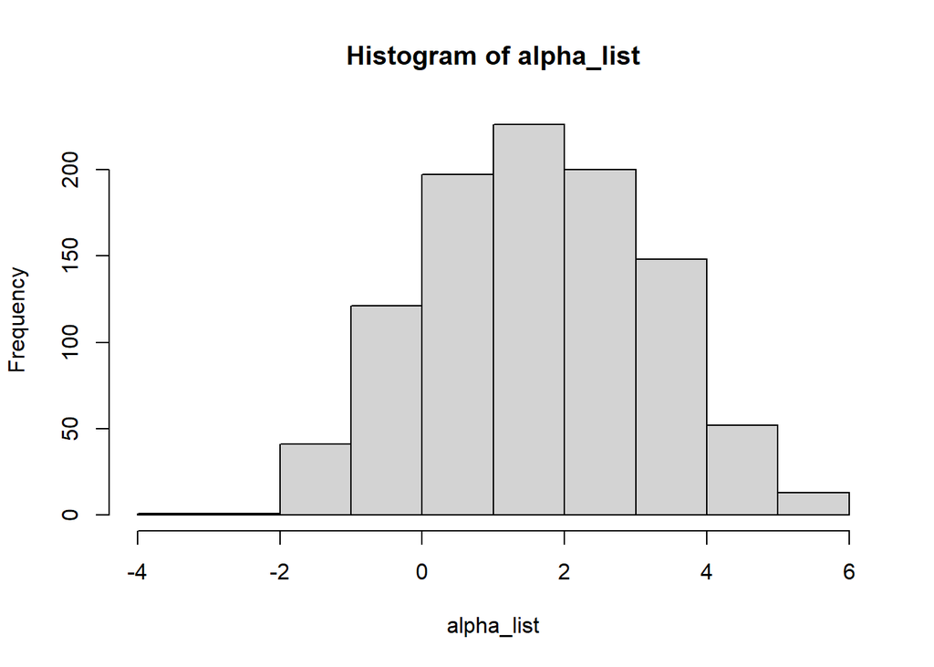

```r
##plotting the frequency of alpha, beta and tau using hist()

hist(alpha_list)
```

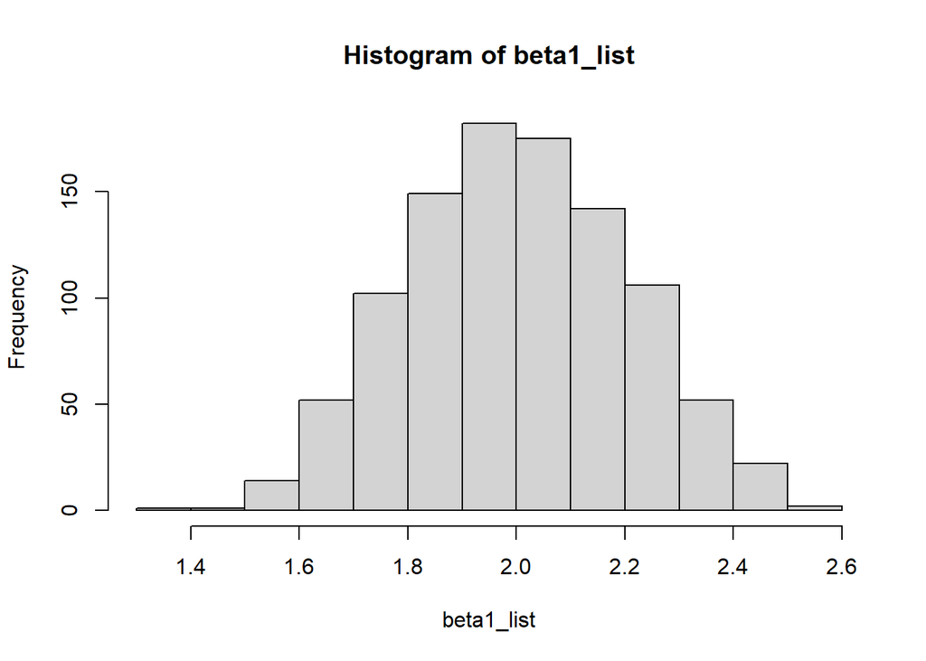

```r
hist(beta1_list)
```

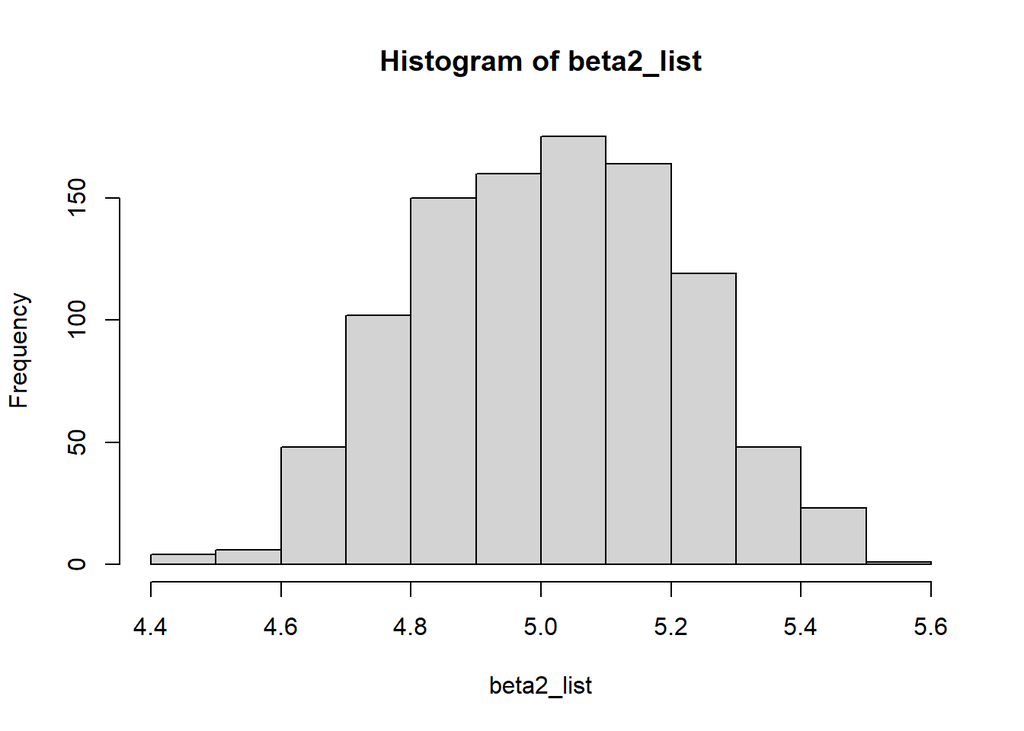

```r
hist(beta2_list)
```

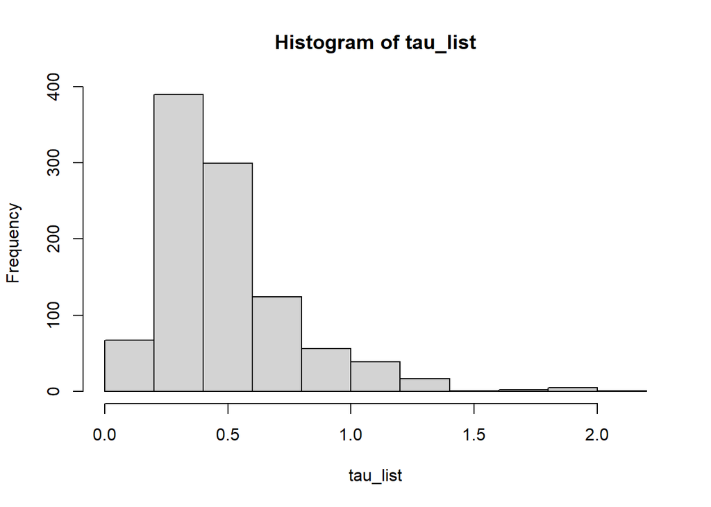

```r
hist(tau_list)
```

```r
lsmeans_results<-lm(y~x_1 + x_2, data)
summary(lsmeans_results)
```

```
##
## Call:
## lm(formula = y ~ x_1 + x_2, data = data)
##
## Residuals:
##     Min      1Q  Median      3Q     Max
## -2.0873 -0.5734  0.0509  0.5538  2.7828
##
## Coefficients:
##             Estimate Std. Error t value Pr(>|t|)
## (Intercept)  1.67714    0.27338   6.135 1.85e-08 ***
## x_1          1.99744    0.03561  56.084  < 2e-16 ***
## x_2          5.01180    0.03464 144.672  < 2e-16 ***
## ---
## Signif. codes:  0 '***' 0.001 '**' 0.01 '*' 0.05 '.' 0.1 ' ' 1
##
## Residual standard error: 0.9663 on 97 degrees of freedom
## Multiple R-squared:  0.9959, Adjusted R-squared:  0.9958
## F-statistic: 1.183e+04 on 2 and 97 DF,  p-value: < 2.2e-16
```

```r
confint(lsmeans_results)
```

```
##                2.5 %   97.5 %
## (Intercept) 1.134562 2.219717
## x_1         1.926758 2.068130
## x_2         4.943045 5.080557
```

```r
anova(lsmeans_results)
```

```
## Analysis of Variance Table
##
## Response: y
##           Df  Sum Sq Mean Sq F value    Pr(>F)
## x_1        1  2547.3  2547.3  2727.9 < 2.2e-16 ***
## x_2        1 19544.0 19544.0 20929.8 < 2.2e-16 ***
## Residuals 97    90.6     0.9
## ---
## Signif. codes:  0 '***' 0.001 '**' 0.01 '*' 0.05 '.' 0.1 ' ' 1
```

```r
sum(lsmeans_results$residuals^2)/qchisq(0.975,df=21)
```

```
## [1] 2.552994
```

```r
sum(lsmeans_results$residuals^2)/qchisq(0.025,df=21)
```

```
## [1] 8.808543
```

MCMC approaches``

1- Metropolis Hasting

sd=sqrt(1/tau)

```r
###Likelihood set up as a function
Params = c(0, 0 , 0.5, 0.5)

likelihood_1 = function(Params){
  alpha = Params[1]
  beta_1 = Params[2]
  beta_2 = Params[3]
  tau = Params[4]

  return(sum(dnorm(y, alpha + beta_1*x_1 + beta_2*x_2, sd = sqrt(1/tau), log = T)))}


likelihood_2 = function(Params){
  alpha = Params[1]
  beta_1 = Params[2]
  beta_2 = Params[3]
  tau = Params[4]


  if (!is.finite(tau) || tau <= 0) return(-Inf)
  mu <- alpha + beta_1 * x_1 + beta_2 * x_2
  expsum <- sum((y - mu)^2)
  n <- length(y)
  return( (n/2) * (log(tau) - log(2*pi)) - (tau/2) * expsum )
}



likelihood_1(Params)
```

```
## [1] -36996.01
```

```r
likelihood_2(Params)
```

```
## [1] -36996.01
```

```r
###prior set up
prior = function(Params){
  alpha = Params[1]
  beta_1 = Params[2]
  beta_2 = Params[3]
  tau = Params[4]

  prior_alpha = dnorm(alpha, alphamean, sd = sqrt(alphavar), log = T)
  prior_beta_1 = dnorm(beta_1, beta_1mean, sd = sqrt(beta_1var), log = T)
  prior_beta_2 = dnorm(beta_2, beta_2mean, sd = sqrt(beta_2var), log = T)
  prior_tau = dgamma(tau, shape = taushape, scale = tauscale, log = T)

  return(prior_alpha+ prior_beta_1 + prior_beta_2 + prior_tau)

}
prior(Params)
```

```
## [1] -10.55504
```

```r
posterior = function(Params){
  if (any(!is.finite(Params))) return(-Inf)
  if (length(Params) < 4) return(-Inf)
  tau = Params[4]
  if (is.na(tau) || tau <= 0) return(-Inf)

  loglik = likelihood_1(Params)
  logprior = prior(Params)

  if (length(logprior) != 1) {
    warning("posterior(): prior() did not return a scalar. Returning -Inf.")
    return(-Inf)
  }
  if (!is.finite(loglik) || !is.finite(logprior)) return(-Inf)

  return(loglik + logprior)
}
posterior(Params)
```

```
## [1] -37006.56
```

```r
###proposal set up
proposalfunction = function(Params){
  alpha = Params[1]
  beta_1 = Params[2]
  beta_2 = Params[3]
  tau = Params[4]

  s_alpha = 0.05
  s_beta1 = 0.05
  s_beta2 = 0.05
  s_logtau = 0.01

  prop_logtau <- rnorm(1, log(tau), s_logtau)
prop_tau     <- exp(prop_logtau)

  proposal = c(rnorm(1, alpha, sd = s_alpha), rnorm(1, beta_1, sd= s_beta1), rnorm(1, beta_2, sd = s_beta2), prop_tau)
  return(proposal)

}

startvalue = c(4,0, 3, 3)
proposalfunction(startvalue)
```

```
## [1]  3.99775345 -0.04039032  2.99848424  3.02629468
```

```r
####function call

run_metropolis_MCMC = function(startvalue, iterations){
    accept = 0
    chain = array(dim = c(iterations+1,4))
    chain[1,] = startvalue
    for (i in 1:iterations){
        proposal = proposalfunction(chain[i,])

        # log-tau random walk is symmetric on log(tau) but not on tau, so add the Jacobian term log(tau*) - log(tau)
        log_ratio = posterior(proposal) - posterior(chain[i,]) + log(proposal[4]) - log(chain[i,4])
        probab = exp(log_ratio)

        if (runif(1) < probab){
            chain[i+1,] = proposal
            accept = accept + 1
        }else{
            chain[i+1,] = chain[i,]
        }
    }
    attr(chain, "accept_rate") <- accept / iterations
    return(chain)
}
```

```r
#tuning
tune = function(startvalue, iterations) {
  chain = run_metropolis_MCMC(startvalue, iterations)
  return(attr(chain, "accept_rate"))}

acceptance = tune(startvalue, 1000)
```

```r
###running a call
iterations = 50000
startvalue = c(4,0, 3, 1)
t_metrop = system.time({chain = run_metropolis_MCMC(startvalue, iterations)}) #Timing metropolis hastings

burnin = 10000
acceptance = 1-mean(duplicated(chain[-(1:burnin),]))

MHalpha<-mean(chain[(burnin+1):nrow(chain),1])
MHbeta_1<-mean(chain[(burnin+1):nrow(chain),2])
MHbeta_2<-mean(chain[(burnin+1):nrow(chain),3])
MHTau<-mean(chain[(burnin+1):nrow(chain),4])

options(max.print=1000)
```

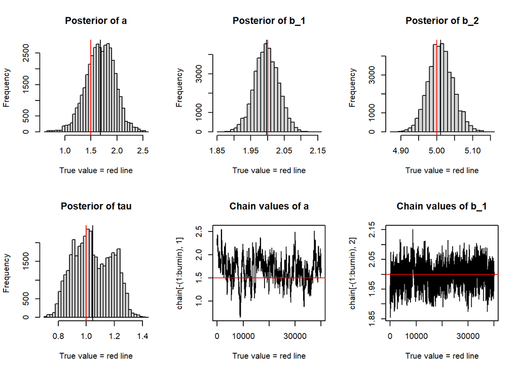

```r
par(mfrow = c(2,3))

#Alpha hist

hist(chain[-(1:burnin),1],nclass=30, main="Posterior of a", xlab="True value = red line" )
abline(v = mean(chain[-(1:burnin),1]))
abline(v = truealpha, col="red" )

#Beta_1 hist

hist(chain[-(1:burnin),2],nclass=30, main="Posterior of b_1", xlab="True value = red line")
abline(v = mean(chain[-(1:burnin),2]))
abline(v = truebeta_1, col="red" )

#Beta_2 hist

hist(chain[-(1:burnin),3],nclass=30, main="Posterior of b_2", xlab="True value = red line")
abline(v = mean(chain[-(1:burnin),3]))
abline(v = truebeta_2, col="red" )

#tau/sd hist

hist(chain[-(1:burnin),4],nclass=30, main="Posterior of tau", xlab="True value = red line")
abline(v = mean(chain[-(1:burnin),4]) )
abline(v = truetau, col="red" )

#Alpha chain values

plot(chain[-(1:burnin),1], type = "l", xlab="True value = red line" , main = "Chain values of a")
abline(h = truealpha, col="red" )

#Beta_1 chain values

plot(chain[-(1:burnin),2], type = "l", xlab="True value = red line" , main = "Chain values of b_1")
abline(h = truebeta_1, col="red" )
```

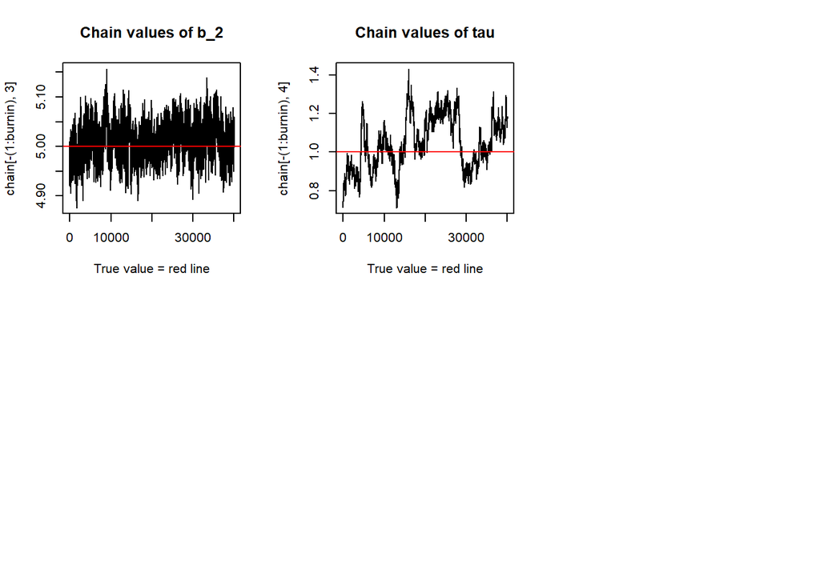

```r
#Beta_2 chain values

plot(chain[-(1:burnin),3], type = "l", xlab="True value = red line" , main = "Chain values of b_2")
abline(h = truebeta_2, col="red" )

#tau/sd chain values

plot(chain[-(1:burnin),4], type = "l", xlab="True value = red line" , main = "Chain values of tau")
abline(h = truetau, col="red" )
```

Traceplot of the above metropolis hastings algorithm (like above but for a png image for the report):

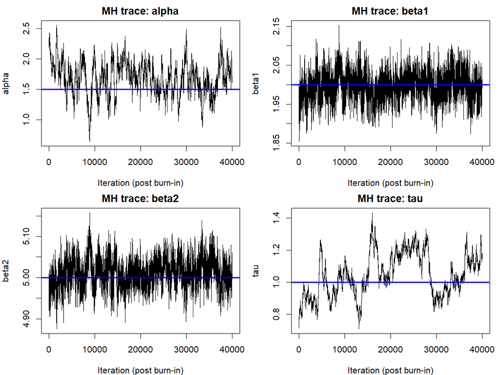

```r
post_mh <- chain[(burnin+1):nrow(chain), ]
colnames(post_mh) <- c("alpha","beta1","beta2","tau")

png("figures/MH_traceplots.png", width = 1200, height = 900, res = 150)
par(mfrow = c(2,2), mar = c(4,4,2,1))

true_vals <- c(alpha = truealpha,
               beta1 = truebeta_1,
               beta2 = truebeta_2,
               tau   = truetau)

for (p in colnames(post_mh)) {
  plot(post_mh[, p], type = "l",
       main = paste("MH trace:", p),
       xlab = "Iteration (post burn-in)",
       ylab = p)
  abline(h = true_vals[p], col = "blue", lwd = 2)
}

invisible(dev.off())
knitr::include_graphics("figures/MH_traceplots.png")
```

Posterior distribution of the MH chain (same as above but just putting it into png):

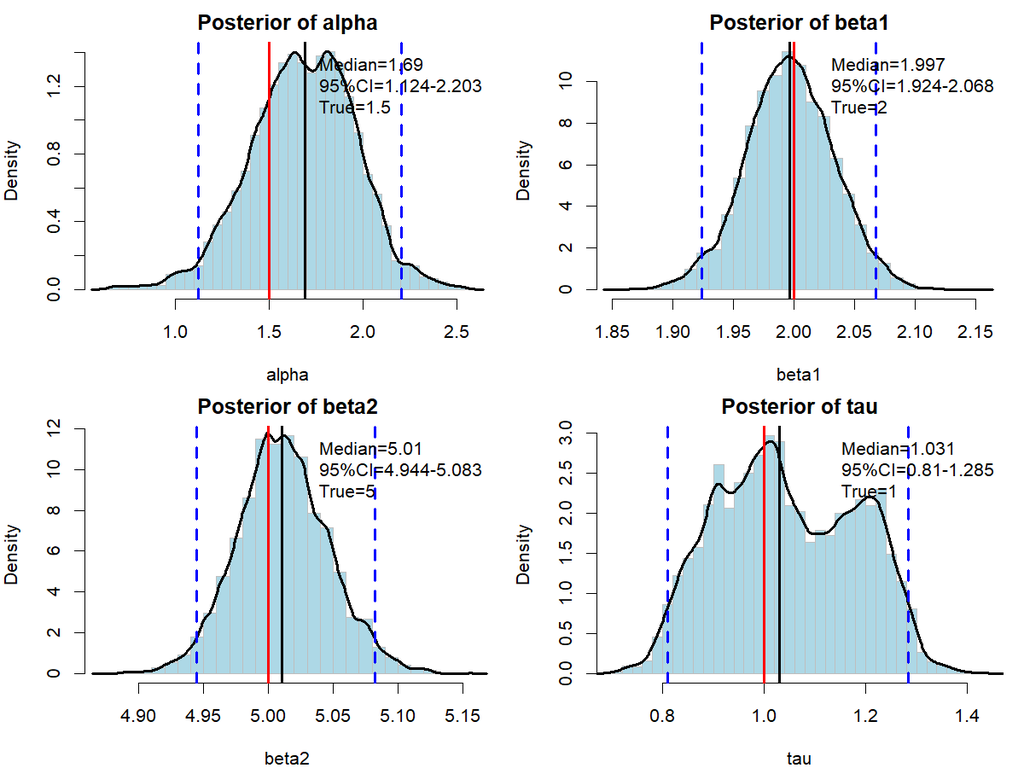

```r
colnames(chain) <- c("alpha","beta1","beta2","tau")


mh_post <- chain[(burnin+1):nrow(chain), ]

true_vals <- c(alpha = truealpha,
               beta1 = truebeta_1,
               beta2 = truebeta_2,
               tau   = truetau)

params <- colnames(mh_post)

png("figures/mh_posterior_histograms.png",
    width = 1200, height = 900, res = 150)

par(mfrow = c(2,2), mar = c(4,4,2,1))

for (p in params) {
  samples <- mh_post[, p]

  h <- hist(samples, breaks = 40, prob = TRUE,
            main = paste("Posterior of", p),
            xlab = p, border = "grey", col = "lightblue")

  d <- density(samples)
  lines(d, lwd = 2)

  ci <- quantile(samples, probs = c(0.025, 0.975))
  abline(v = ci, lty = 2, lwd = 2, col = "blue")

  med <- median(samples)
  abline(v = med, lty = 1, lwd = 2, col = "black")

  true_val <- true_vals[p]
  abline(v = true_val, col = "red", lwd = 2)

  legend("topright",
         legend = c(
           paste0("Median=", round(med, 3)),
           paste0("95%CI=", round(ci[1], 3), "-", round(ci[2], 3)),
           paste0("True=",   round(true_val, 3))
         ),
         bty = "n")
}

invisible(dev.off())
knitr::include_graphics("figures/mh_posterior_histograms.png")
```

Autocorrelation graph:

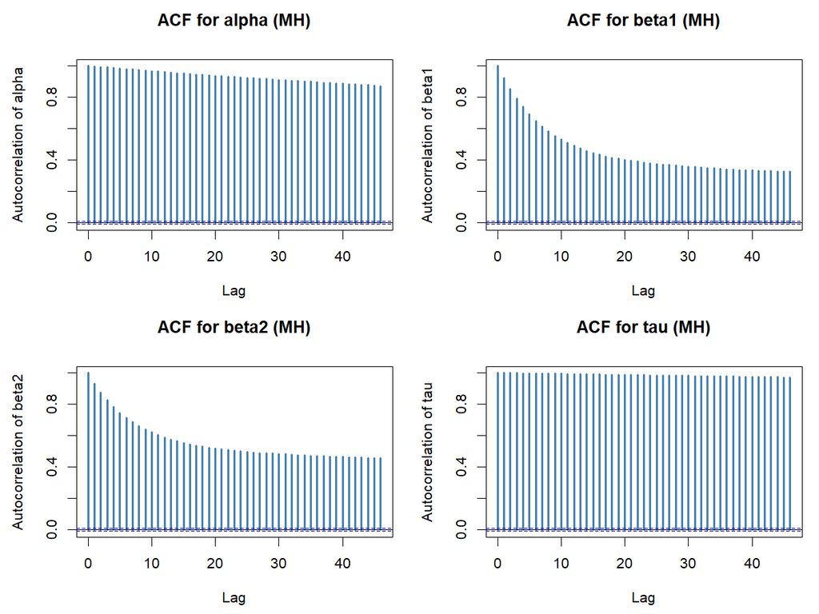

```r
post_mh <- chain[(burnin+1):nrow(chain), ]
colnames(post_mh) <- c("alpha","beta1","beta2","tau")

png("figures/acf_plots_MH_pretty.png", width = 1200, height = 900, res = 150)

par(mfrow = c(2,2), mar = c(4.5,4.5,3.5,1))

for (p in colnames(post_mh)) {
  acf(post_mh[, p],
      main = paste("ACF for", p, "(MH)"),
      xlab = "Lag",
      ylab = paste("Autocorrelation of", p),
      col  = "steelblue",
      lwd  = 2)
}

invisible(dev.off())
knitr::include_graphics("figures/acf_plots_MH_pretty.png")
```

Gibbs Sampling

We need the conditional probability distributions for each parameter:

```r
#install.packages("coda")
library(coda)

gibbs_simple <- function(y, x1, x2,
                         niter,
                         alphamean, alphavar,
                         beta1mean, beta1var,
                         beta2mean, beta2var,
                         taushape, taurate,
                         start) {
  n <- length(y)
  if (length(x1) != n || length(x2) != n) stop("y, x1, x2 must have same length")

  if (is.null(start)) {
    alpha <- mean(y)
    beta1 <- 0
    beta2 <- 0
    tau   <- 1
  } else {
    alpha <- start[1]; beta1 <- start[2]; beta2 <- start[3]; tau <- start[4]
  }

  chain <- matrix(NA, nrow = niter, ncol = 4)
  colnames(chain) <- c("alpha", "beta1", "beta2", "tau")

  for (it in 1:niter) {
    ## sample alpha | beta1,beta2,tau,y  (univariate normal)
    sum_res <- 0.0
    for (i in 1:n) {
      sum_res <- sum_res + (y[i] - beta1 * x1[i] - beta2 * x2[i])
    }
    prec_alpha <- tau * n + 1 / alphavar
    var_alpha  <- 1 / prec_alpha
    mean_alpha <- var_alpha * (tau * sum_res + alphamean / alphavar)
    alpha <- rnorm(1, mean_alpha, sqrt(var_alpha))

    ## sample beta1 | alpha,beta2,tau,y  (univariate normal)
    sum_x1sq <- 0.0
    sum_x1res <- 0.0
    for (i in 1:n) {
      sum_x1sq <- sum_x1sq + (x1[i]^2)
      sum_x1res <- sum_x1res + (x1[i] * (y[i] - alpha - beta2 * x2[i]))
    }
    prec_beta1 <- tau * sum_x1sq + 1 / beta1var
    var_beta1  <- 1 / prec_beta1
    mean_beta1 <- var_beta1 * (tau * sum_x1res + beta1mean / beta1var)
    beta1 <- rnorm(1, mean_beta1, sqrt(var_beta1))

    ## sample beta2 | alpha,beta1,tau,y  (univariate normal)
    sum_x2sq <- 0.0
    sum_x2res <- 0.0
    for (i in 1:n) {
      sum_x2sq <- sum_x2sq + (x2[i]^2)
      sum_x2res <- sum_x2res + (x2[i] * (y[i] - alpha - beta1 * x1[i]))
    }
    prec_beta2 <- tau * sum_x2sq + 1 / beta2var
    var_beta2  <- 1 / prec_beta2
    mean_beta2 <- var_beta2 * (tau * sum_x2res + beta2mean / beta2var)
    beta2 <- rnorm(1, mean_beta2, sqrt(var_beta2))

    ## sample tau | alpha,beta1,beta2,y  (Gamma, rate parameterization)
    sse <- 0.0
    for (i in 1:n) {
      resid <- y[i] - alpha - beta1 * x1[i] - beta2 * x2[i]
      sse <- sse + resid^2
    }
    post_shape <- taushape + n / 2
    post_rate  <- taurate + 0.5 * sse
    tau <- rgamma(1, shape = post_shape, rate = post_rate)

    chain[it, ] <- c(alpha, beta1, beta2, tau)
  }

  return(chain)
}
```

```r
iterations = 50000
t_gibbs <- system.time({gibbs_chain <- gibbs_simple(y, x_1, x_2, niter = iterations,
                      alphamean, alphavar,
                      beta_1mean, beta_1var,
                      beta_2mean, beta_2var,
                      taushape, taurate = 1/taushape, startvalue)})

# posterior means (after discarding the first 10,000 draws as burn-in)
burnin = 10000
prediction <- colMeans(gibbs_chain[(burnin+1):iterations, ])
Gibbs_alpha <- prediction[1]
Gibbs_beta1 <- prediction[2]
Gibbs_beta2 <- prediction[3]
Gibbs_tau <- prediction[4]
```

Now we get confidence intervals for each parameter:

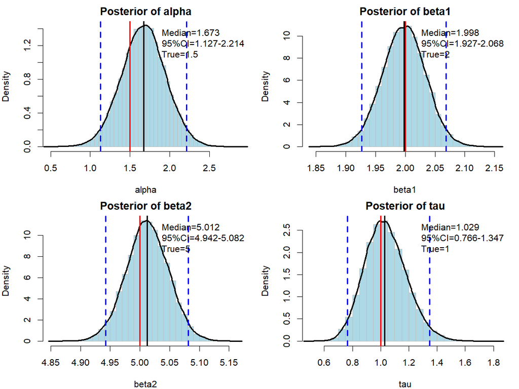

```r
colnames(gibbs_chain) <- c("alpha","beta1","beta2","tau")

chain_post <- gibbs_chain[(burnin+1):nrow(gibbs_chain), ]

true_vals <- c(alpha = truealpha, beta1 = truebeta_1, beta2 = truebeta_2, tau = truetau)
params <- colnames(chain_post)

png("figures/posterior_histograms.png", width = 1200, height = 900, res = 150)
par(mfrow = c(2,2), mar = c(4,4,2,1))

for (p in params) {
  samples <- chain_post[, p]
  h <- hist(samples, breaks = 40, prob = TRUE,
            main = paste("Posterior of", p),
            xlab = p, border = "grey", col = "lightblue")
  d <- density(samples)
  lines(d, lwd = 2)
  ci <- quantile(samples, probs = c(0.025, 0.975))
  abline(v = ci, lty = 2, lwd = 2, col = "blue")
  abline(v = median(samples), lty = 1, lwd = 2, col = "black")
  lines_x <- true_vals[p]
  abline(v = lines_x, col = "red", lwd = 2)
  legend("topright", legend = c(paste0("Median=", round(median(samples),3)),
                                paste0("95%CI=", round(ci[1],3), "-", round(ci[2],3)),
                                paste0("True=", round(lines_x,3))),
         bty = "n")
}
invisible(dev.off())
knitr::include_graphics("figures/posterior_histograms.png")
```

Plotting histograms for a single run:

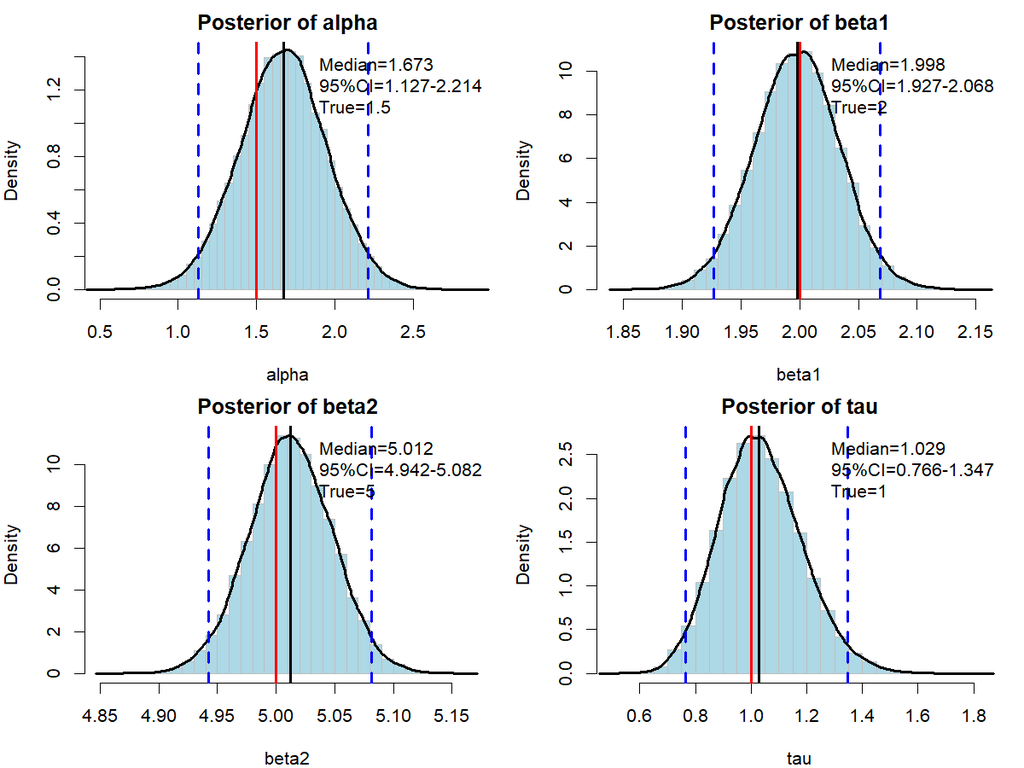

```r
colnames(gibbs_chain) <- c("alpha","beta1","beta2","tau")
chain_post <- gibbs_chain[(burnin+1):nrow(gibbs_chain), ]

true_vals <- c(alpha = truealpha, beta1 = truebeta_1, beta2 = truebeta_2, tau = truetau)
params <- colnames(chain_post)

png("figures/gibbs_posterior_histograms.png", width = 1200, height = 900, res = 150)
par(mfrow = c(2,2), mar = c(4,4,2,1))

for (p in params) {
  samples <- chain_post[, p]
  h <- hist(samples, breaks = 40, prob = TRUE,
            main = paste("Posterior of", p),
            xlab = p, border = "grey", col = "lightblue")
  d <- density(samples)
  lines(d, lwd = 2)
  ci <- quantile(samples, probs = c(0.025, 0.975))
  abline(v = ci, lty = 2, lwd = 2, col = "blue")
  abline(v = median(samples), lty = 1, lwd = 2, col = "black")
  lines_x <- true_vals[p]
  abline(v = lines_x, col = "red", lwd = 2)
  legend("topright", legend = c(paste0("Median=", round(median(samples),3)),
                                paste0("95%CI=", round(ci[1],3), "-", round(ci[2],3)),
                                paste0("True=", round(lines_x,3))),
         bty = "n")
}
invisible(dev.off())
knitr::include_graphics("figures/gibbs_posterior_histograms.png")
```

Simulation: Simulating 1000 responses (y), keeping inputs (x) fixed, and running the gibbs sampler for each set of responses.

```r
B      <- 1000        # number of simulated datasets
niter_sim  <- 5000   # shorter chains for the 1,000-dataset simulation
burnin_sim <- 2500   # separate names so the main-run burn-in (10,000) is not overwritten

means_mat <- matrix(NA, nrow = B, ncol = 4)
colnames(means_mat) <- c("alpha","beta1","beta2","tau")

ci_lower <- matrix(NA, nrow = B, ncol = 4)
ci_upper <- matrix(NA, nrow = B, ncol = 4)
colnames(ci_lower) <- colnames(ci_upper) <- colnames(means_mat)

for (b in 1:B) {

  eps_b <- rnorm(n, mean = 0, sd = sqrt(1/truetau))
  y_b   <- truealpha + truebeta_1 * x_1 + truebeta_2 * x_2 + eps_b

  gibbs_chain_b <- gibbs_simple(
    y_b, x_1, x_2,
    niter = niter_sim,
    alphamean, alphavar,
    beta_1mean, beta_1var,
    beta_2mean, beta_2var,
    taushape, taurate = 1/taushape,
    startvalue
  )

  post_b <- gibbs_chain_b[(burnin_sim+1):niter_sim, ]
  colnames(post_b) <- c("alpha","beta1","beta2","tau")

  means_mat[b, ] <- colMeans(post_b)

  ci_lower[b, ] <- apply(post_b, 2, quantile, probs = 0.025)
  ci_upper[b, ] <- apply(post_b, 2, quantile, probs = 0.975)
}
```

Coverage of the 95% credible intervals across the 1,000 simulated datasets (share of datasets whose interval contains the true value):

```r
true_vals <- c(alpha = truealpha, beta1 = truebeta_1, beta2 = truebeta_2, tau = truetau)
coverage <- sapply(colnames(means_mat), function(p) mean(ci_lower[, p] <= true_vals[p] & true_vals[p] <= ci_upper[, p]))
round(coverage, 3)
```

```
## alpha beta1 beta2   tau
## 0.953 0.953 0.957 0.964
```

Analytics of the gibbs sampler and checking that the analytic and frequentist approach agrees

```r
tau_draws <- gibbs_chain[, "tau"]

mean_tau   <- mean(tau_draws)
median_tau <- median(tau_draws)
sd_tau     <- sd(tau_draws)
mode_tau   <- function(x) {
  d <- density(x)
  d$x[which.max(d$y)]
}
mode_tau_est <- mode_tau(tau_draws)
ci_tau <- quantile(tau_draws, c(0.025, 0.975))

cat("tau mean:", mean_tau, "\n")
```

```
## tau mean: 1.035914
```

```r
cat("tau median:", median_tau, "\n")
```

```
## tau median: 1.0299
```

```r
cat("tau mode (approx):", mode_tau_est, "\n")
```

```
## tau mode (approx): 1.036654
```

```r
cat("tau sd:", sd_tau, "\n")
```

```
## tau sd: 0.1490369
```

```r
cat("95% CI:", ci_tau, "\n")
```

```
## 95% CI: 0.7642327 1.34655
```

```r
sigma_draws <- 1 / sqrt(tau_draws)
cat("sigma mean:", mean(sigma_draws), " median:", median(sigma_draws), " sd:", sd(sigma_draws), "\n")
```

```
## sigma mean: 0.9908095  median: 0.9853771  sd: 0.0922066
```

Plotting on a histogram:

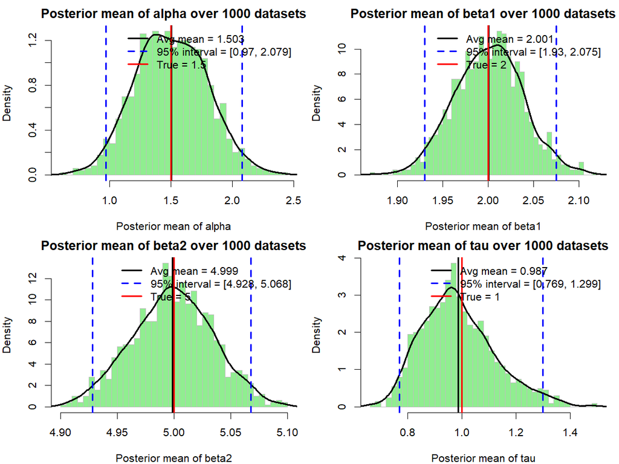

```r
true_vals <- c(alpha = truealpha,
               beta1 = truebeta_1,
               beta2 = truebeta_2,
               tau   = truetau)

png("figures/hist_gibbs_posterior_means_across_simulations.png",
    width = 1200, height = 900, res = 150)
par(mfrow = c(2,2), mar = c(4,4,2,1))

for (p in colnames(means_mat)) {
  vals <- means_mat[, p]

  ci <- quantile(vals, probs = c(0.025, 0.975))

  h <- hist(vals, breaks = 40, prob = TRUE,
            main = paste("Posterior mean of", p, "over 1000 datasets"),
            xlab = paste("Posterior mean of", p),
            col = "lightgreen", border = "grey")

  lines(density(vals), lwd = 2)

  abline(v = mean(vals), col = "black", lwd = 2)

  abline(v = true_vals[p], col = "red", lwd = 2)

  abline(v = ci, col = "blue", lwd = 2, lty = 2)

  legend("topright",
         legend = c(
           paste0("Avg mean = ", round(mean(vals), 3)),
           paste0("95% interval = [", round(ci[1], 3), ", ", round(ci[2], 3), "]"),
           paste0("True = ", round(true_vals[p], 3))
         ),
         col = c("black","blue","red"),
         lwd = c(2,2,2),
         lty = c(1,2,1),
         bty = "n")
}
invisible(dev.off())
knitr::include_graphics("figures/hist_gibbs_posterior_means_across_simulations.png")
```

Traceplot of gibbs sampler

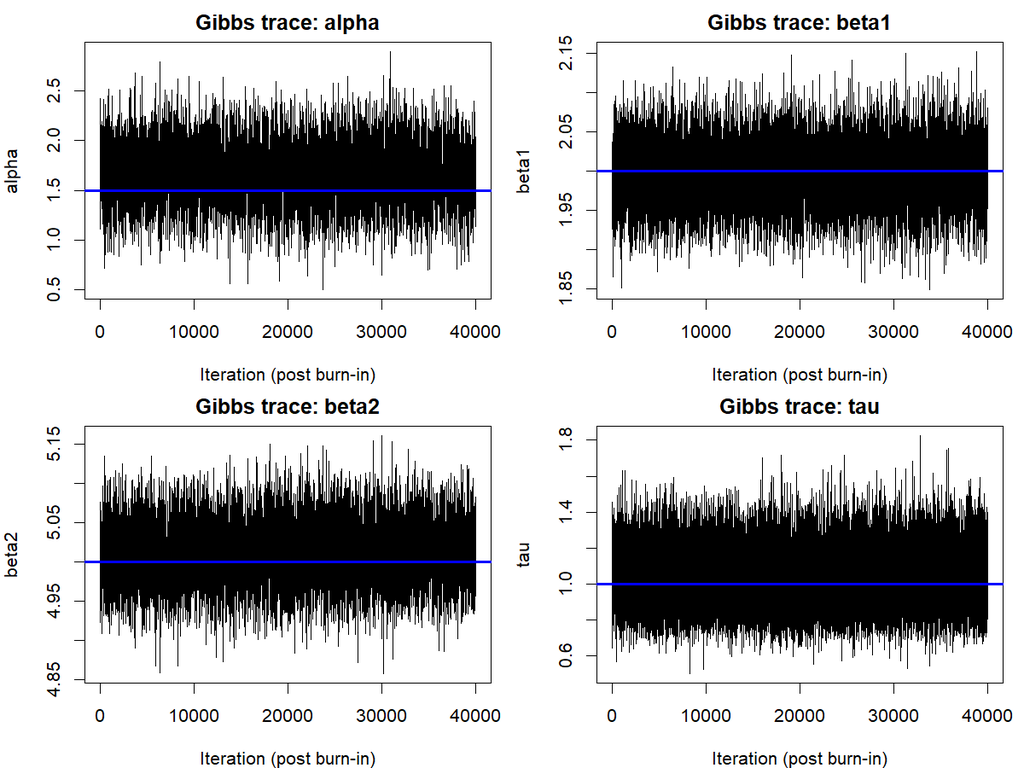

```r
gibbs_post <- gibbs_chain[(burnin+1):nrow(gibbs_chain), ]
colnames(gibbs_post) <- c("alpha","beta1","beta2","tau")

true_vals <- c(alpha = truealpha,
               beta1 = truebeta_1,
               beta2 = truebeta_2,
               tau   = truetau)

png("figures/Gibbs_traceplots.png",
    width = 1200, height = 900, res = 150)

par(mfrow = c(2,2), mar = c(4,4,2,1))

for (p in colnames(gibbs_post)) {
  plot(gibbs_post[, p], type = "l",
       main = paste("Gibbs trace:", p),
       xlab = "Iteration (post burn-in)",
       ylab = p)
  abline(h = true_vals[p], col = "blue", lwd = 2)
}

invisible(dev.off())
knitr::include_graphics("figures/Gibbs_traceplots.png")
```

Auto-correlation plot of gibbs sampler chain

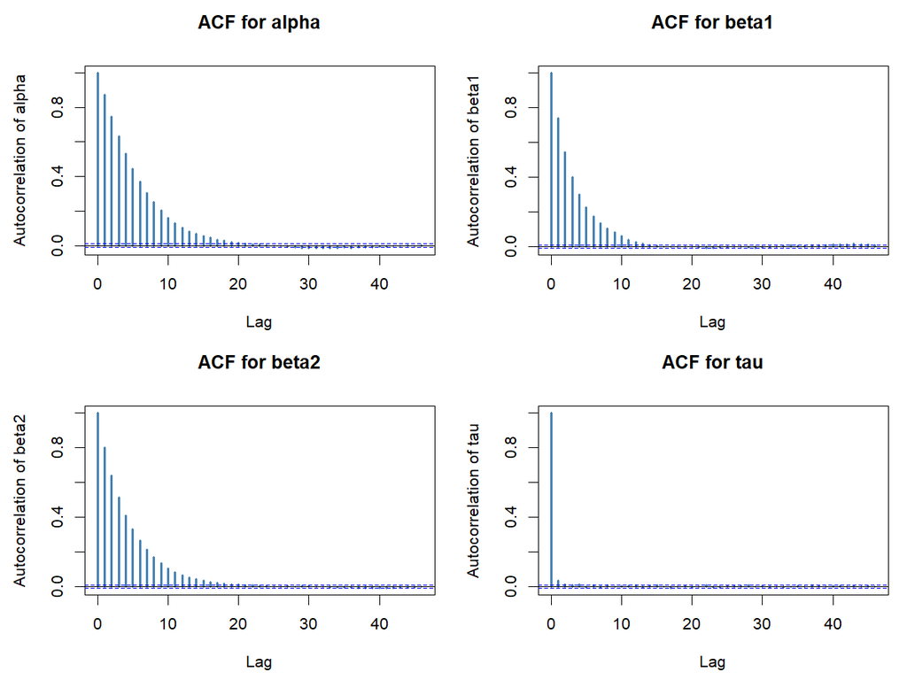

```r
post <- gibbs_chain[(burnin+1):nrow(gibbs_chain), ]
colnames(post) <- c("alpha","beta1","beta2","tau")

true_vals <- c(alpha = truealpha,
               beta1 = truebeta_1,
               beta2 = truebeta_2,
               tau   = truetau)

png("figures/acf_plots_pretty.png", width = 1200, height = 900, res = 150)

par(mfrow = c(2,2), mar = c(4.5,4.5,3.5,1))

for (p in colnames(post)) {

  acf(post[,p],
      main = paste("ACF for", p),
      xlab = "Lag",
      ylab = paste("Autocorrelation of", p),
      col  = "steelblue",
      lwd  = 2)

}

invisible(dev.off())
knitr::include_graphics("figures/acf_plots_pretty.png")
```

Running means for gibbs sampler:

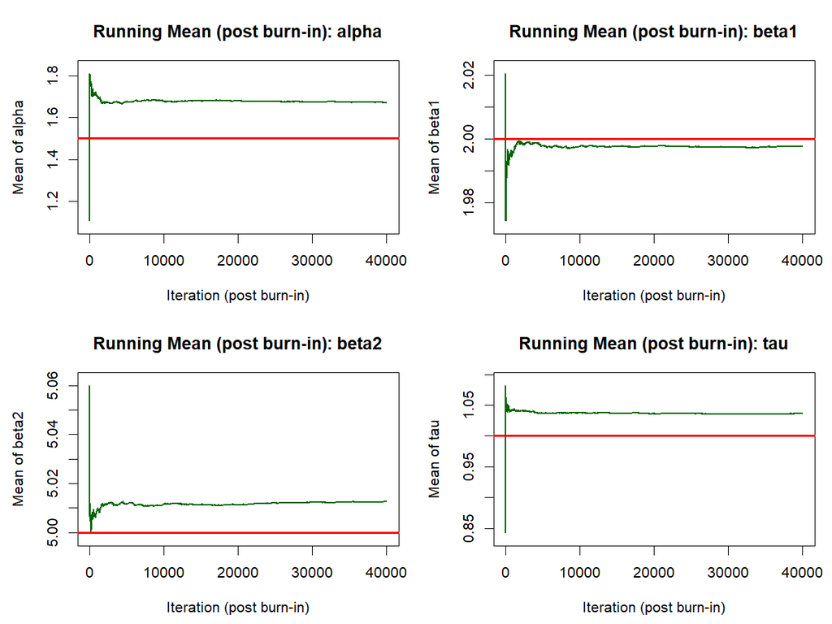

```r
post <- gibbs_chain[(burnin+1):nrow(gibbs_chain), ]
colnames(post) <- c("alpha","beta1","beta2","tau")

running_mean <- function(x) cumsum(x) / seq_along(x)

true_vals <- c(alpha = truealpha,
               beta1 = truebeta_1,
               beta2 = truebeta_2,
               tau   = truetau)

png("figures/running_means_fixed.png", width = 1200, height = 900, res = 150)
par(mfrow = c(2,2), mar = c(4.5,4.5,3.5,1))

for (p in colnames(post)) {
  rm_vals <- running_mean(post[, p])

  y_min <- min(rm_vals, true_vals[p])
  y_max <- max(rm_vals, true_vals[p])
  pad   <- 0.05 * (y_max - y_min + 1e-8)
  ylim  <- c(y_min - pad, y_max + pad)

  plot(rm_vals, type = "l", col = "darkgreen", lwd = 1.5,
       main = paste("Running Mean (post burn-in):", p),
       xlab = "Iteration (post burn-in)",
       ylab = paste("Mean of", p),
       ylim = ylim)

  abline(h = true_vals[p], col = "red", lwd = 2)
}

invisible(dev.off())
knitr::include_graphics("figures/running_means_fixed.png")
```

Now using the r package MCMCPack to compare with the gibbs sampler:

```r
#install.packages("MCMCpack")
#install.packages("MatrixModels")
library(MCMCpack)
data_gibbs <- data.frame(y = y, x_1 = x_1, x_2 = x_2)

b0 <- c(alphamean, beta_1mean, beta_2mean)

B0 <- diag(c(1/alphavar, 1/beta_1var, 1/beta_2var))


c0 <- 2 * taushape
d0 <- 2 * 1/taushape #taurate


niter = 50000
burnin = 10000
mcmc_iters <- niter - burnin


t_package <- system.time({fit_mcmcpack <- MCMCregress(
  y ~ x_1 + x_2,
  data   = data_gibbs,
  burnin = burnin,
  mcmc   = mcmc_iters,
  b0     = b0,
  B0     = B0,
  c0     = c0,
  d0     = d0
)})

summary(fit_mcmcpack)
```

```
##
## Iterations = 10001:50000
## Thinning interval = 1
## Number of chains = 1
## Sample size per chain = 40000
##
## 1. Empirical mean and standard deviation for each variable,
##    plus standard error of the mean:
##
##               Mean      SD  Naive SE Time-series SE
## (Intercept) 1.6789 0.28136 0.0014068      0.0014099
## x_1         1.9972 0.03651 0.0001826      0.0001826
## x_2         5.0117 0.03564 0.0001782      0.0001757
## sigma2      0.9845 0.14388 0.0007194      0.0007454
##
## 2. Quantiles for each variable:
##
##              2.5%    25%    50%   75% 97.5%
## (Intercept) 1.125 1.4889 1.6817 1.866 2.229
## x_1         1.927 1.9724 1.9975 2.022 2.069
## x_2         4.942 4.9877 5.0116 5.036 5.082
## sigma2      0.742 0.8835 0.9712 1.071 1.303
```

Comparing

```r
#install.packages("rmarkdown")
library(rmarkdown)
colnames(gibbs_chain) <- c("alpha","beta1","beta2","tau")
post_gibbs <- gibbs_chain[(burnin+1):nrow(gibbs_chain), ]


post_mcmc <- as.matrix(fit_mcmcpack)
colnames(post_mcmc)
```

```
## [1] "(Intercept)" "x_1"         "x_2"         "sigma2"
```

```r
tau_mcmc <- 1 / post_mcmc[,"sigma2"]


post_mcmc_aligned <- cbind(
  alpha = post_mcmc[,"(Intercept)"],
  beta1 = post_mcmc[,"x_1"],
  beta2 = post_mcmc[,"x_2"],
  tau   = tau_mcmc
)


means_gibbs <- colMeans(post_gibbs)
means_mcmc  <- colMeans(post_mcmc_aligned)

comparison_means <- cbind(
  My_Gibbs = round(means_gibbs, 4),
  MCMCpack    = round(means_mcmc, 4),
  True        = c(truealpha, truebeta_1, truebeta_2, truetau)
)
comparison_means
```

```
##       My_Gibbs MCMCpack True
## alpha   1.6715   1.6789  1.5
## beta1   1.9977   1.9972  2.0
## beta2   5.0125   5.0117  5.0
## tau     1.0362   1.0369  1.0
```

```r
summ_fun <- function(m) {
  rbind(
    mean  = apply(m, 2, mean),
    sd    = apply(m, 2, sd),
    q025  = apply(m, 2, quantile, 0.025),
    q975  = apply(m, 2, quantile, 0.975)
  )
}

summ_gibbs <- round(summ_fun(post_gibbs), 4)
summ_mcmc  <- round(summ_fun(post_mcmc_aligned), 4)


cat("\nPosterior Summary Table - My Gibbs Sampler\n")
```

```
##
## Posterior Summary Table - My Gibbs Sampler
```

```r
print(summ_gibbs)
```

```
##       alpha  beta1  beta2    tau
## mean 1.6715 1.9977 5.0125 1.0362
## sd   0.2767 0.0361 0.0355 0.1484
## q025 1.1267 1.9267 4.9424 0.7658
## q975 2.2138 2.0684 5.0817 1.3474
```

```r
kable(summ_gibbs,
      caption = "Posterior Summary: My Gibbs Sampler")
```

Posterior Summary: My Gibbs Sampler

|  | alpha | beta1 | beta2 | tau |
| --- | --- | --- | --- | --- |
| mean | 1.6715 | 1.9977 | 5.0125 | 1.0362 |
| sd | 0.2767 | 0.0361 | 0.0355 | 0.1484 |
| q025 | 1.1267 | 1.9267 | 4.9424 | 0.7658 |
| q975 | 2.2138 | 2.0684 | 5.0817 | 1.3474 |

```r
cat("\nPosterior Summary Table - MCMCpack\n")
```

```
##
## Posterior Summary Table - MCMCpack
```

```r
print(summ_mcmc)
```

```
##       alpha  beta1  beta2    tau
## mean 1.6789 1.9972 5.0117 1.0369
## sd   0.2814 0.0365 0.0356 0.1482
## q025 1.1252 1.9266 4.9421 0.7676
## q975 2.2293 2.0691 5.0816 1.3477
```

```r
kable(summ_mcmc,
      caption = "Posterior Summary: Package Gibbs Sampler")
```

Posterior Summary: Package Gibbs Sampler

|  | alpha | beta1 | beta2 | tau |
| --- | --- | --- | --- | --- |
| mean | 1.6789 | 1.9972 | 5.0117 | 1.0369 |
| sd | 0.2814 | 0.0365 | 0.0356 | 0.1482 |
| q025 | 1.1252 | 1.9266 | 4.9421 | 0.7676 |
| q975 | 2.2293 | 2.0691 | 5.0816 | 1.3477 |

```r
cat("\nComparison of Posterior Means:\n")
```

```
##
## Comparison of Posterior Means:
```

```r
print(comparison_means)
```

```
##       My_Gibbs MCMCpack True
## alpha   1.6715   1.6789  1.5
## beta1   1.9977   1.9972  2.0
## beta2   5.0125   5.0117  5.0
## tau     1.0362   1.0369  1.0
```

```r
kable(comparison_means,
      caption = "Comparison of Parameter means between MCMC package and my code")
```

Comparison of Parameter means between MCMC package and my code

|  | My_Gibbs | MCMCpack | True |
| --- | --- | --- | --- |
| alpha | 1.6715 | 1.6789 | 1.5 |
| beta1 | 1.9977 | 1.9972 | 2.0 |
| beta2 | 5.0125 | 5.0117 | 5.0 |
| tau | 1.0362 | 1.0369 | 1.0 |

Overlay posterior distributions

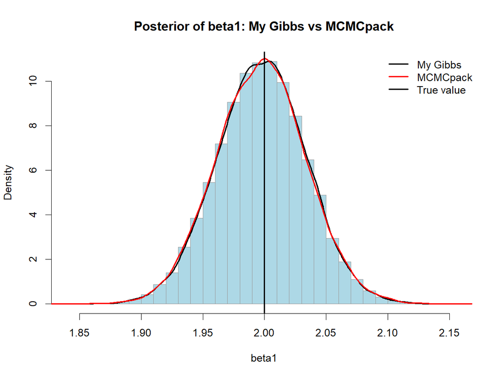

```r
png("figures/Overlay_comparison_gibbs.png",
    width = 1200, height = 900, res = 150)

gibbs_beta1 <- post_gibbs[,"beta1"]
pack_beta1  <- post_mcmc_aligned[,"beta1"]

hist(gibbs_beta1, breaks = 40, prob = TRUE,
     main = "Posterior of beta1: My Gibbs vs MCMCpack",
     xlab = "beta1", col = "lightblue", border = "grey60")

lines(density(gibbs_beta1), lwd = 2)
lines(density(pack_beta1),  col = "red", lwd = 2) # MCMCpack
abline(v = truebeta_1, col = "black", lwd = 2)

legend("topright",
       legend = c("My Gibbs", "MCMCpack", "True value"),
       col    = c("black","red","black"),
       lwd    = c(2,2,2),
       bty    = "n")

invisible(dev.off())
knitr::include_graphics("figures/Overlay_comparison_gibbs.png")
```

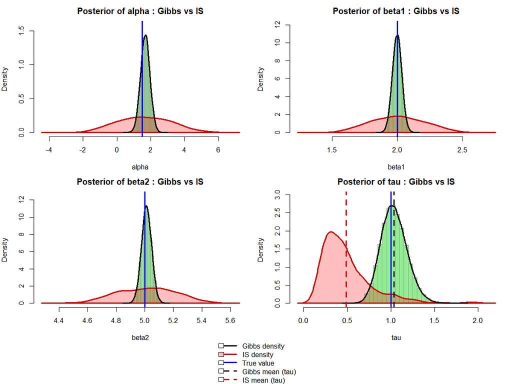

```r
post_gibbs <- gibbs_chain[(burnin+1):nrow(gibbs_chain), ]
colnames(post_gibbs) <- c("alpha","beta1","beta2","tau")

post_IS <- cbind(
  alpha = alpha_list,
  beta1 = beta1_list,
  beta2 = beta2_list,
  tau   = tau_list
)

true_vals <- c(alpha = truealpha,
               beta1 = truebeta_1,
               beta2 = truebeta_2,
               tau   = truetau)

png("figures/IS_vs_Gibbs_densities.png",
    width = 1200, height = 900, res = 150)

layout(matrix(c(1,2,
                3,4,
                5,5), nrow = 3, byrow = TRUE),
       heights = c(1,1,0.25))

par(mar = c(4,4,2.5,1))

for (p in colnames(post_IS)) {

  x_IS    <- post_IS[, p]
  x_gibbs <- post_gibbs[, p]

  dens_IS    <- density(x_IS,    adjust = 1.2)
  dens_gibbs <- density(x_gibbs, adjust = 1.2)

  x_min <- min(dens_IS$x, dens_gibbs$x, true_vals[p])
  x_max <- max(dens_IS$x, dens_gibbs$x, true_vals[p])
  y_max <- 1.1 * max(dens_IS$y, dens_gibbs$y)

  hist(x_gibbs,
       breaks = 40,
       freq   = FALSE,
       xlim   = c(x_min, x_max),
       ylim   = c(0, y_max),
       main   = paste("Posterior of", p, ": Gibbs vs IS"),
       xlab   = p,
       ylab   = "Density",
       col    = "lightgreen",
       border = "grey60")

  polygon(dens_IS$x, dens_IS$y,
          col    = rgb(1, 0, 0, 0.25),
          border = "red3", lwd = 2)

  lines(dens_gibbs, col = "black", lwd = 2)

  abline(v = true_vals[p], col = "blue", lwd = 2)

  if (p == "tau") {
    mean_gibbs <- mean(x_gibbs)
    mean_IS    <- mean(x_IS)
    abline(v = mean_gibbs, col = "black", lwd = 2, lty = 2)
    abline(v = mean_IS,    col = "red3",  lwd = 2, lty = 2)
  }
}

par(mar = c(0,0,0,0))
plot.new()
legend("center",
       legend = c("Gibbs density", "IS density", "True value",
                  "Gibbs mean (tau)", "IS mean (tau)"),
       col    = c("black", "red3", "blue", "black", "red3"),
       lwd    = c(2,2,2,2,2),
       lty    = c(1,1,1,2,2),
       bty    = "n",
       fill   = c(NA, rgb(1,0,0,0.25), NA, NA, NA))

invisible(dev.off())
knitr::include_graphics("figures/IS_vs_Gibbs_densities.png")
```

Final comparison table !

```r
library(knitr)

true_vals <- c(alpha = truealpha,
               beta1 = truebeta_1,
               beta2 = truebeta_2,
               tau   = truetau)


post_gibbs <- gibbs_chain[(burnin+1):nrow(gibbs_chain), ]
colnames(post_gibbs) <- c("alpha","beta1","beta2","tau")
gibbs_means <- colMeans(post_gibbs)

post_IS <- cbind(
  alpha = alpha_list,
  beta1 = beta1_list,
  beta2 = beta2_list,
  tau   = tau_list
)
is_means <- colMeans(post_IS)

mcmc_means <- colMeans(post_mcmc_aligned)

post_mh <- chain[(burnin+1):nrow(chain), ]
colnames(post_mh) <- c("alpha","beta1","beta2","tau")
mh_means <- colMeans(post_mh)


time_gibbs   <- as.numeric(t_gibbs["elapsed"])
time_package <- as.numeric(t_package["elapsed"])
time_IS      <- as.numeric(t_is["elapsed"])
time_ml      <- as.numeric(t_ml["elapsed"])
time_mh      <- as.numeric(t_metrop["elapsed"])


summary_table <- rbind(
  "True values"          = c(true_vals,      Time_sec = NA),
  "Maximum likelihood"   = c(ml_results,     Time_sec = time_ml),
  "Gibbs (mine)"         = c(gibbs_means,    Time_sec = time_gibbs),
  "Gibbs (MCMCpack)"     = c(mcmc_means,     Time_sec = time_package),
  "Metropolis-Hastings"  = c(mh_means,       Time_sec = time_mh),
  "Importance sampling"  = c(is_means,       Time_sec = time_IS)
)


method_rows <- setdiff(rownames(summary_table), "True values")

estimates <- summary_table[method_rows, 1:4]

rmse <- sqrt(rowMeans((sweep(estimates, 2, true_vals, FUN = "-"))^2))

summary_table <- cbind(summary_table,
                       RMSE = c(NA, rmse[rownames(summary_table)[-1]]))

summary_table <- round(summary_table, 4)


kable(summary_table,
      caption = "True parameter values, point/posterior estimates, runtimes (seconds), and overall RMSE for each method.",
      digits = 4)
```

True parameter values, point/posterior estimates, runtimes (seconds), and overall RMSE for each method.

|  | alpha | beta1 | beta2 | tau | Time_sec | RMSE |
| --- | --- | --- | --- | --- | --- | --- |
| True values | 1.5000 | 2.0000 | 5.0000 | 1.0000 | NA | NA |
| Maximum likelihood | 1.6771 | 1.9974 | 5.0118 | 1.0709 | 0.00 | 0.0956 |
| Gibbs (mine) | 1.6715 | 1.9977 | 5.0125 | 1.0362 | 2.50 | 0.0879 |
| Gibbs (MCMCpack) | 1.6789 | 1.9972 | 5.0117 | 1.0369 | 0.65 | 0.0915 |
| Metropolis-Hastings | 1.6821 | 1.9970 | 5.0113 | 1.0452 | 2.49 | 0.0940 |
| Importance sampling | 1.6371 | 2.0038 | 5.0136 | 0.4879 | 771.93 | 0.2651 |

Effective sample size (post burn-in) for Gibbs vs Metropolis-Hastings, and per second of run time:

```r
post_gibbs_ess <- gibbs_chain[(burnin+1):nrow(gibbs_chain), c("alpha","beta1","beta2","tau")]
post_mh_ess    <- chain[(burnin+1):nrow(chain), c("alpha","beta1","beta2","tau")]
ess_table <- rbind(
  Gibbs = effectiveSize(as.mcmc(post_gibbs_ess)),
  MH    = effectiveSize(as.mcmc(post_mh_ess))
)
round(ess_table, 0)
```

```
##       alpha beta1 beta2   tau
## Gibbs  3454  6064  4485 35425
## MH       69   465   262    14
```

```r
round(ess_table / c(as.numeric(t_gibbs["elapsed"]), as.numeric(t_metrop["elapsed"])), 1)  # ESS per second
```

```
##        alpha  beta1  beta2     tau
## Gibbs 1381.7 2425.7 1793.9 14169.9
## MH      27.7  186.8  105.3     5.6
```